# Healthcare Linear Regression

Author

“Kristin Lloyd”

```r
library(readr)
df <- read_csv("../data/clean_data/merged_data.csv")
head(df)
```

```
# A tibble: 6 × 98
  State     parental_leave_manda…¹ parental_leave_manda…² parental_leave_volun…³
  <chr>                      <dbl>                  <dbl>                  <dbl>
1 Alabama                        0                      0                      1
2 Alaska                         0                      0                      0
3 Arizona                        0                      0                      0
4 Arkansas                       0                      0                      1
5 Californ…                      1                      0                      0
6 Colorado                       1                      0                      0
# ℹ abbreviated names: ¹parental_leave_mandatory_enacted,
#   ²parental_leave_mandatory_not_yet_enacted, ³parental_leave_voluntary
# ℹ 94 more variables: parental_leave_job_protection <dbl>,
#   num_weeks_parental_leave <dbl>, percent_women_working <dbl>,
#   pctg_women_uninsured <dbl>, avg_infant_childcare_price_2018 <dbl>,
#   avg_infant_childcare_price_2023 <dbl>,
#   avg_infant_childcare_price_as_share_of_fam_income_2018 <dbl>, …
```

```r
options(repos = c(CRAN = "https://cran.r-project.org"))
install.packages("dplyr")
library(dplyr)
```

```r
library(ggplot2)
library(tidyr)
library(dplyr)
```

# Linear Regression

```r
policy_order <- c("most protective", "very protective", "protective",
                 "some restrictions/protections", "restrictive",
                 "very restrictive", "most restrictive")
```

```r
create_policy_viz <- function(data, metric_col, title, y_label, plot_type = "bar") {
  processed_data <- data %>%
    filter(!is.na(abortion_policies) &
           abortion_policies != "" &
           abortion_policies != "NA") %>%
    mutate(abortion_policies = tolower(trimws(abortion_policies))) %>%
    group_by(abortion_policies) %>%
    summarise(avg_value = mean(!!sym(metric_col), na.rm = TRUE)) %>%
    filter(abortion_policies %in% policy_order) %>%
    mutate(
      abortion_policies = factor(abortion_policies, levels = policy_order),
      policy_numeric = as.numeric(factor(abortion_policies, levels = policy_order))
    )

  p <- ggplot(processed_data, aes(x = abortion_policies, y = avg_value))

  if(plot_type == "scatter") {
    model <- lm(avg_value ~ policy_numeric, data = processed_data)
    r_squared <- round(summary(model)$r.squared, 3)

    p <- p +
      geom_point(size = 4, color = "steelblue") +
      geom_smooth(aes(x = policy_numeric), method = "lm", se = TRUE, color = "red") +
      annotate("text",
              x = length(policy_order) - 0.5,
              y = max(processed_data$avg_value),
              label = paste0("R² = ", r_squared),
              size = 4, hjust = 1)
  } else {
    p <- p + geom_bar(stat = "identity", fill = "steelblue")
  }

  p + labs(
    title = title,
    x = "Abortion Policy",
    y = y_label
  ) +
    theme_minimal() +
    theme(
      axis.text.x = element_text(angle = 45, hjust = 1),
      plot.title = element_text(hjust = 0.5, size = 14, face = "bold"),
      axis.title = element_text(size = 12)
    )
}
```

## Health Ranking

```r
health_ranking <- create_policy_viz(df,
    "overall_health_ranking",
    "Overall Health Ranking",
    "Ranking",
    "scatter")
```

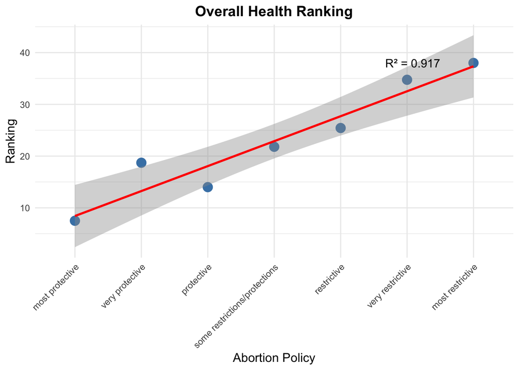

```r
print(health_ranking)
```

### Interpretation

R-squared is .917, showing strong linear correlation.

### Ideas

1. Use Courtney’s exact map code that plots which state is most predictive, most restrictive, etc. Then place the health ranking number on top of each state. Or put a star on the state if it is over ranking 25 (since 25 is mid), or can try higher numbers.
2. Correlation map with other variables.

## Coverage, Access, Affordability

```r
coverage_access_affordability <- create_policy_viz(df,
    "coverage_access_and_affordability",
    "Coverage, Access, and Affordability",
    "Ranking",
    "scatter")
```

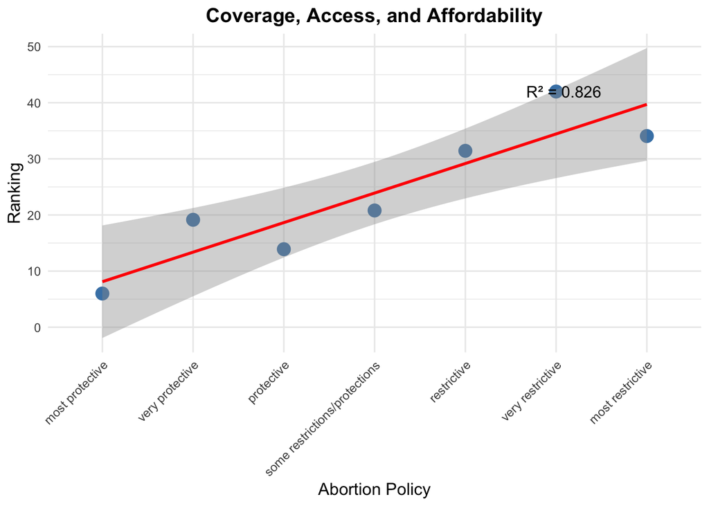

```r
print(coverage_access_affordability)
```

### Interpretation

R-squared is .826, showing strong linear correlation.

### Ideas

1. Use Courtney’s exact map code that plots which state is most predictive, most restrictive, etc. Then place the health ranking number on top of each state. Or put a star on the state if it is over ranking 25 (since 25 is mid), or can try higher numbers.
2. Correlation map with other variables.

## Healthcare Quality

```r
healthcare_quality_prevention <- create_policy_viz(df,
    "health_care_quality_and_prevention",
    "Healthcare Quality and Prevention",
    "Ranking",
    "scatter")
```

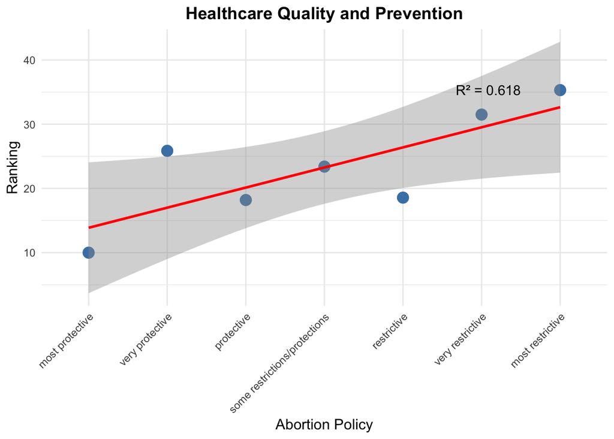

```r
print(healthcare_quality_prevention)
```

### Interpretation

R-squared is .618, showing somewhat of a correlation.

### Ideas

1. Use Courtney’s exact map code that plots which state is most predictive, most restrictive, etc. Then place the health ranking number on top of each state. Or put a star on the state if it is over ranking 25 (since 25 is mid), or can try higher numbers.
2. Correlation map with other variables.

## Health Outcomes

```r
health_outcomes <- create_policy_viz(df,
    "health_outcomes",
    "Health Outcomes",
    "Ranking",
    "scatter")
```

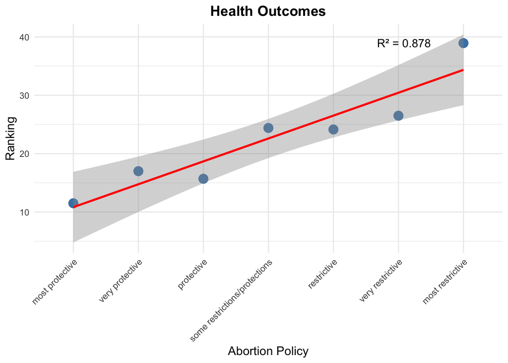

```r
print(health_outcomes)
```

### Interpretation

R-squared is .878, showing a strong linear correlation.

### Ideas

1. Use Courtney’s exact map code that plots which state is most predictive, most restrictive, etc. Then place the health ranking number on top of each state. Or put a star on the state if it is over ranking 25 (since 25 is mid), or can try higher numbers.
2. Correlation map with other variables, especially above ones.

## Healthcare Cost

```r
healthcare_cost <- create_policy_viz(df,
   "women_18_44_who_went_without_care_because_of_cost.1",
   "Women Without Care Due to Cost",
   "Percentage",
   "scatter")
```

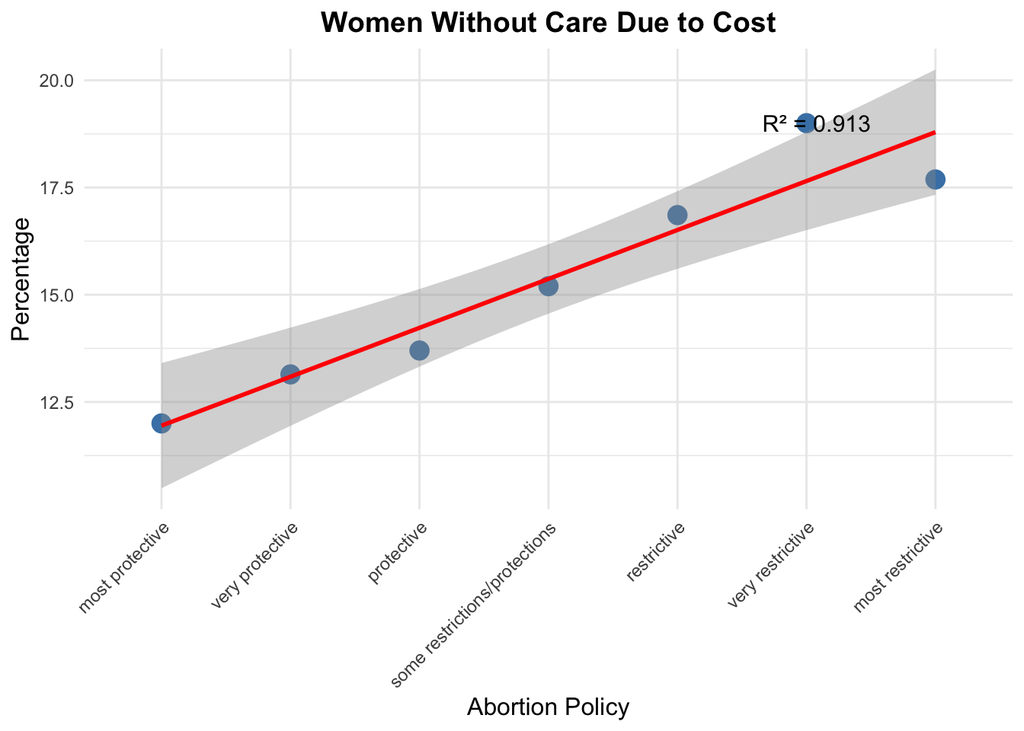

```r
print(healthcare_cost)
```

### Interpretation

R-squared is .913, showing a strong linear correlation.

### Ideas

1. Use Courtney’s exact map code that plots which state is most predictive, most restrictive, etc. Then place star on state if women went without care due to cost percentage is above ___. We can fill in the blank with the average percentage of all the states.

## Uninsured Women

```r
uninsured_women <- create_policy_viz(df,
   "percent_uninsured_women_ages 19_64",
   "Uninsured Women Ages 19-64",
   "Percentage",
   "scatter")
```

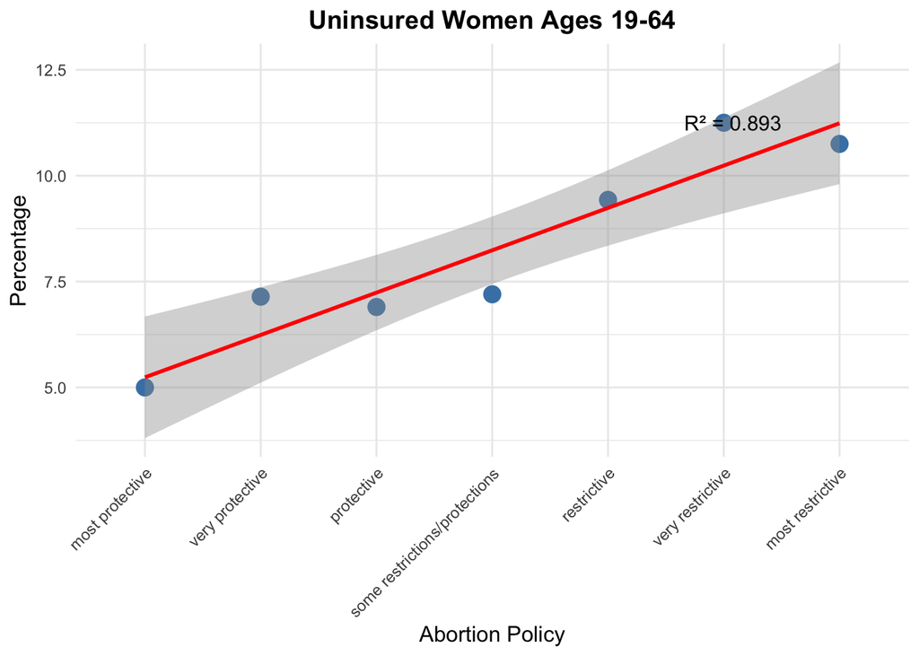

```r
print(uninsured_women)
```

### Interpretation

R-squared is .893, showing a strong linear correlation.

### Ideas

Honestly running out of ideas

## Uninsured during pregnancy

```r
uninsured_pregnancy <- create_policy_viz(df,
   "percent_uninsured_women_during_pregnancy_2021",
   "Uninsured During Pregnancy",
   "Percentage",
   "scatter")
```

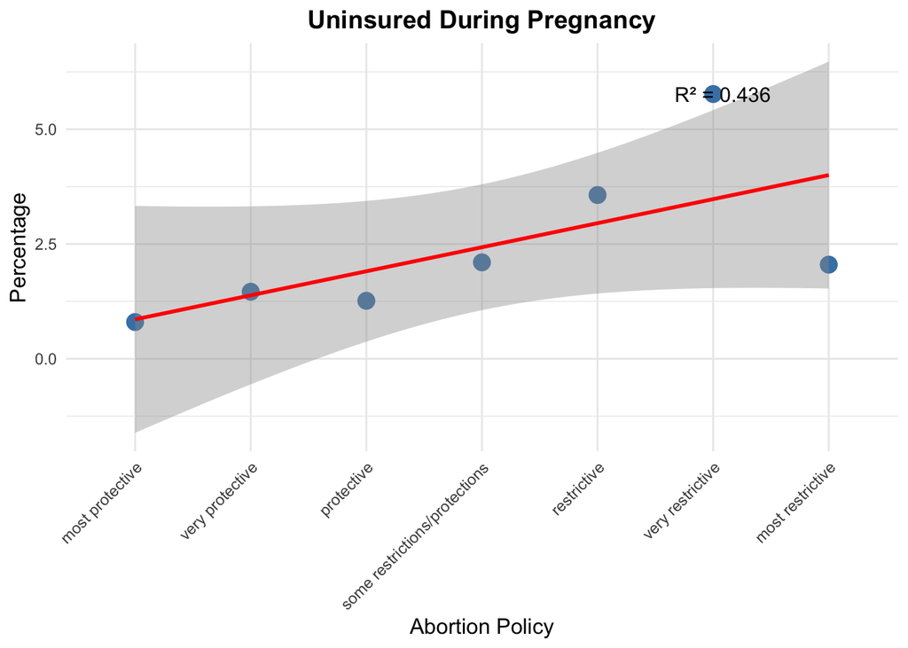

```r
print(uninsured_pregnancy)
```

### Interpretation

R-squared is .436, showing a poor fit.

### Ideas

What else can we do? Actually shows that most restrictive states have a low number of women uninsured. We might want to get rid of this plot all together.

## Teen Birth

```r
teen_birth <- create_policy_viz(df,
   "teen_birth_rate_per_1,000_population_ages_15_19_2022.1",
   "Teen Birth Rate",
   "Rate per 1,000",
   "scatter")
```

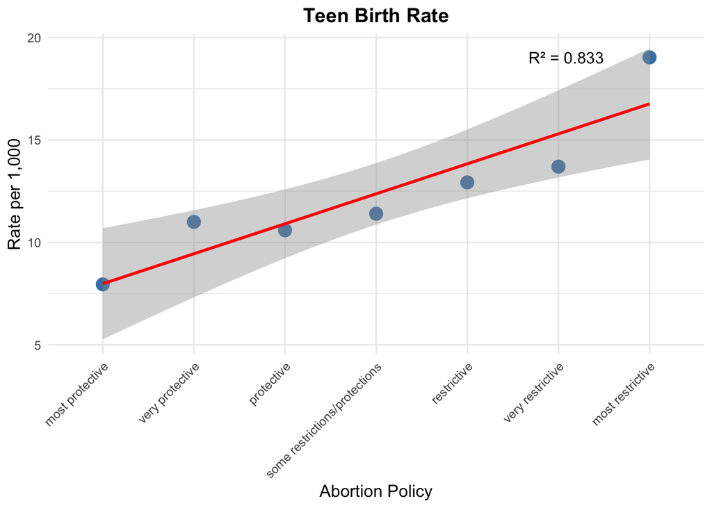

```r
print(teen_birth)
```

### Interpretation

R-squared is .8333, showing strong linear correlation. If teens are giving birth at higher rates in abortion ban states, they may not reach their full potential education wise. Further, these teenagers are probably not financially stable when giving birth. Teen births are extremely high in most restrictive states.

### Ideas

What plot can we use to show how high rates are in most restrictive states?

1. Box plot
2. Correlation with education and maternal workforce
3. Correlation with concraception coverage required by state
4. Correlation with other columns?

## All Birth

```r
all_birth <- create_policy_viz(df,
   "birth_rate_per_1,000_women_ages_15_44",
   "Birth Rate",
   "Rate per 1,000",
   "scatter")
```

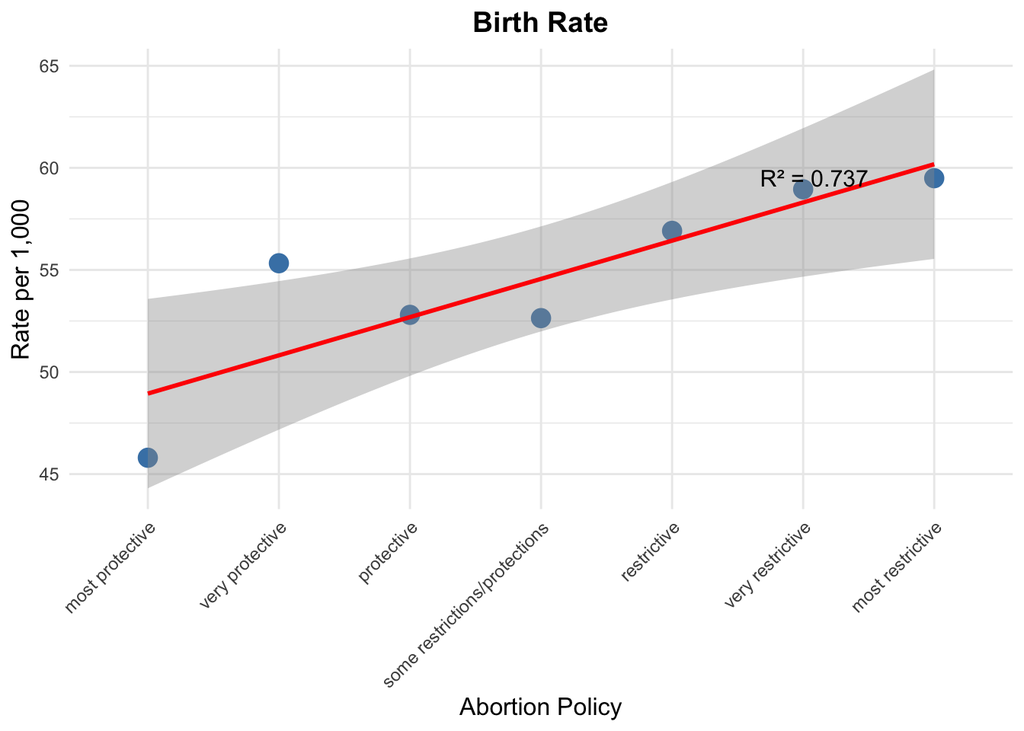

```r
print(all_birth)
```

### Interpretation

R-squared is .73, states with stricter abortion bans seem to have higher birth rates.

### Ideas

Do we really care? I guess it shows more women are giving birth into these horrible conditions. Might be a good way to start our presentation!

## Workforce

```r
workforce <- create_policy_viz(df,
   "maternity_care_workforce_per_100,000_women_ages_15_44",
   "Maternity Care Workforce",
   "Per 100,000 Women",
   "scatter")
```

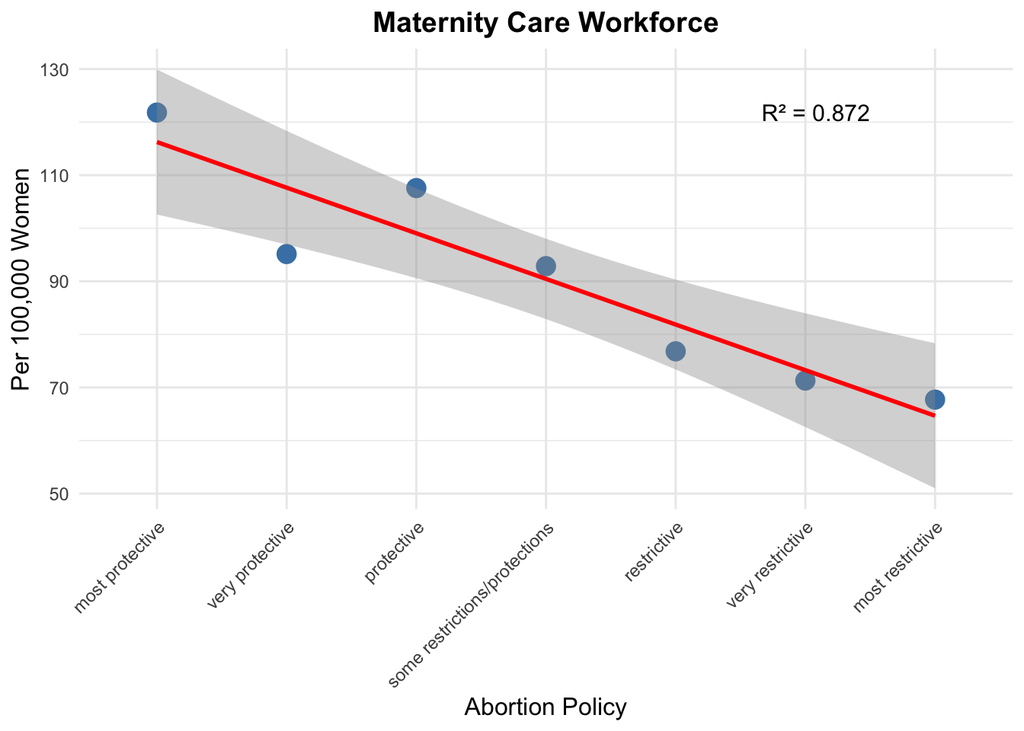

```r
print(workforce)
```

### Interpretation

R-squred is .872 and R is negative.

### Ideas

What plots can we use to show that mothers are in the workforce less in restrictive states?

1. Correlation plots

```r
no_care <- create_policy_viz(df,
   "percent_women_ages_18_44_without_a_usual_source_of_care",
   "Women Without Usual Source of Care",
   "Percentage",
   "scatter")
```

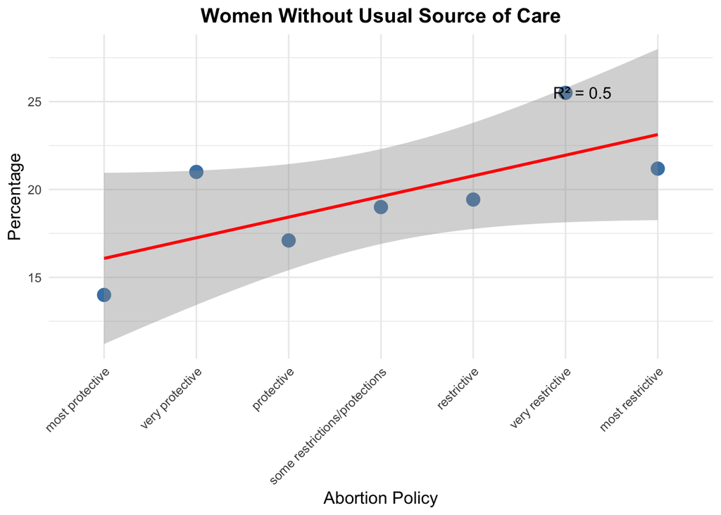

```r
print(no_care)
```

### Interpretation

R-squared is .5, not really sure there is much we can do with this.

### Ideas

I don’t think we need this column.

## Medicaid Births

```r
medicaid_births <- create_policy_viz(df,
   "percent_of_births_financed_by_medicaid",
   "Births Financed by Medicaid",
   "Percentage",
   "scatter")
```

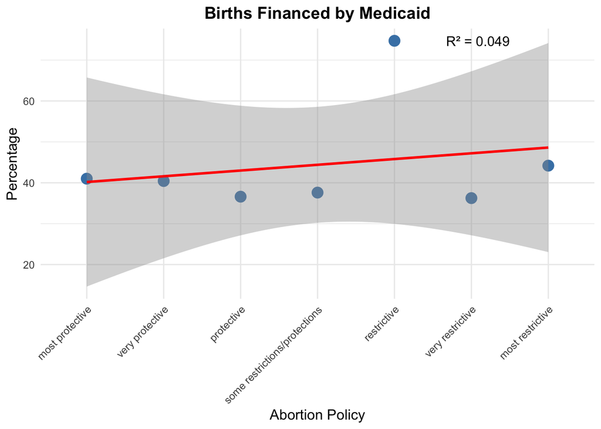

```r
print(medicaid_births)
```

### Interpretation

R-squared is 0.049, no correlation.

### Ideas

Does medicaid births not having a correlation mean anything for our project? I don’t think we need this column.

## Depression

```r
depression <- create_policy_viz(df,
   "women_with_depression_before_or_during_pregnancy_2021",
   "Depression Before/During Pregnancy",
   "Percentage",
   "scatter")
```

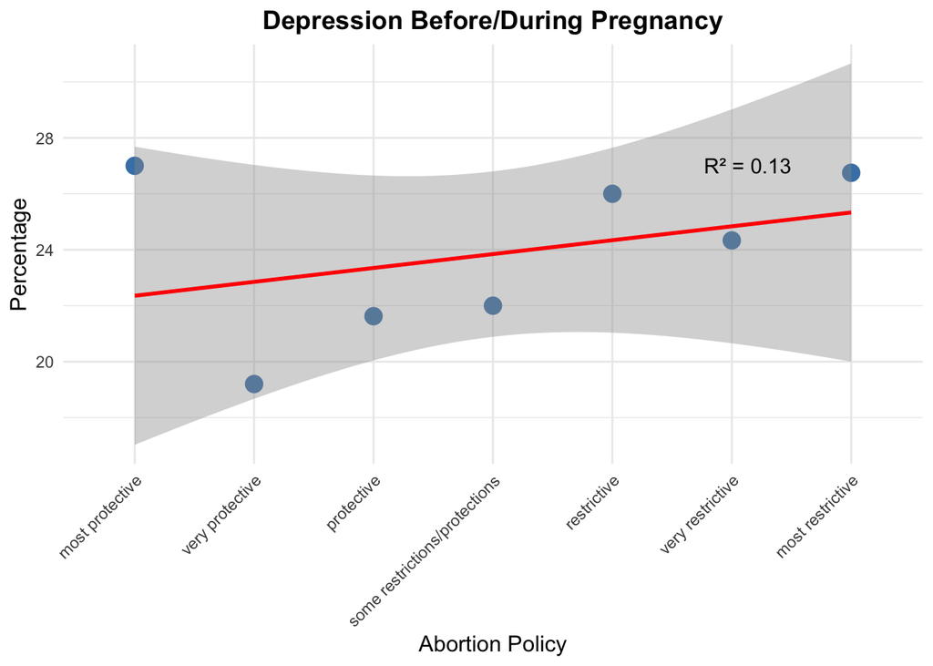

```r
print(depression)
```

### Interpretation

R-squared is 0.13, depression is very common.

### Ideas

We can use this to say women are depressed or just get rid of it.

## Postpartum depression

```r
postpartum_depression <- create_policy_viz(df,
   "percent_women_with_postpartum_depression_2021",
   "Postpartum Depression",
   "Percentage",
   "scatter")
```

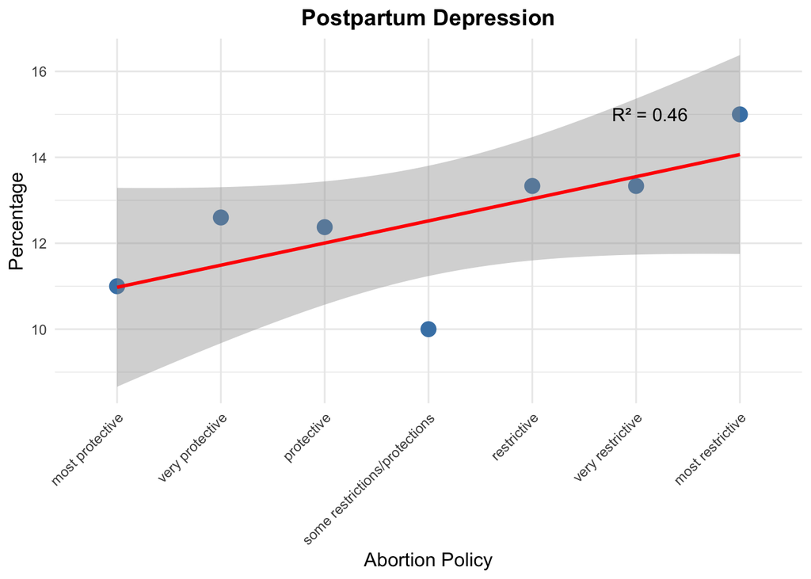

```r
print(postpartum_depression)
```

### Interpretation

R-squared is .46, no correlation but significantly higher during most restrictive states. How can we show this?

### Ideas

1. Maybe we can compare most restrictive to all other categories

## Depression Screenings

```r
depression_screening <- create_policy_viz(df,
   "percent_women_who_received_a_postpartum_depression_screening_2021",
   "Postpartum Depression Screening",
   "Percentage",
   "scatter")
```

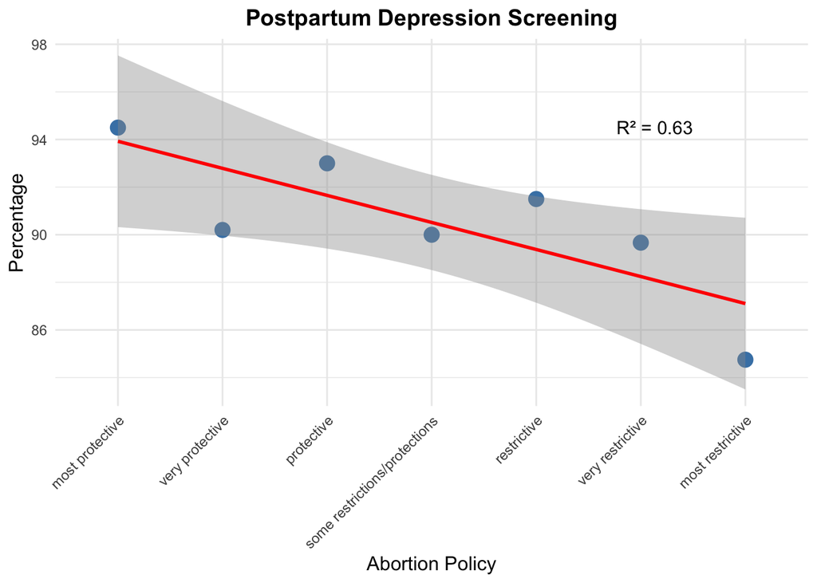

```r
print(depression_screening)
```

### Interpretation

R-squared is .63 and negative, shows that women are given less screenings in abortion ban states. It is exceptionally low for most restrictive states.

### Ideas

1. We could show that depression screenings are not correlated with level of depression! Instead, they are correlated with abortion policy. I really like this.

### Violence

```r
violence <- create_policy_viz(df,
   "percent_women_experiencing_intimate_partner_violence_2021",
   "Intimate Partner Violence",
   "Percentage",
   "scatter")
```

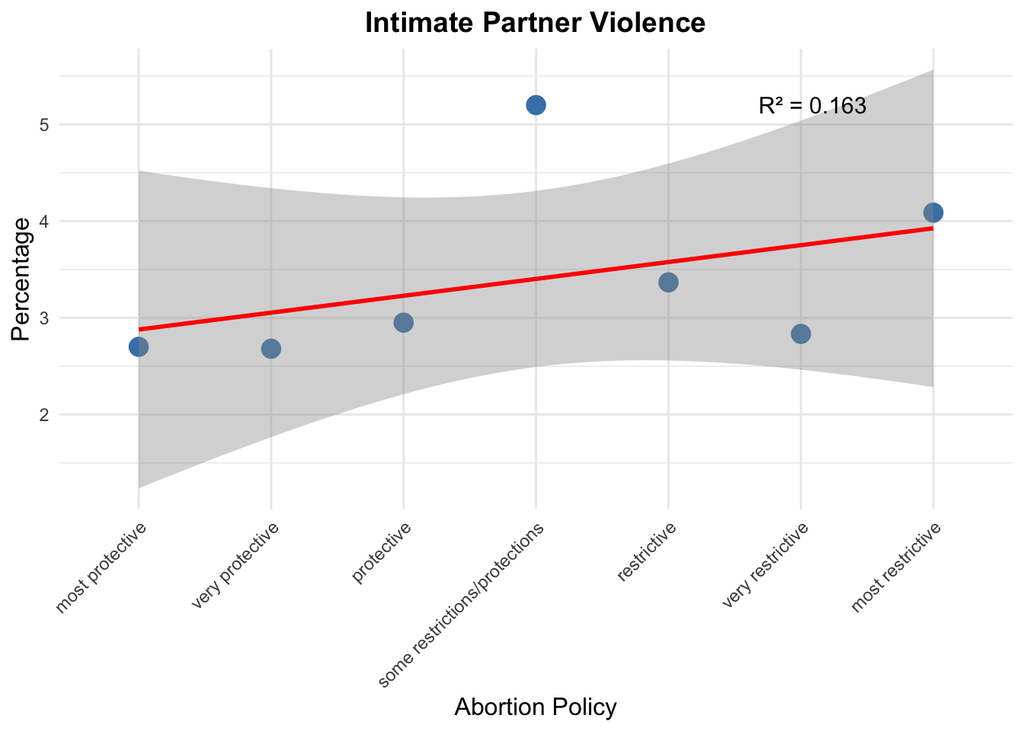

```r
print(violence)
```

### Interpretation

R-squared is .163, no correlation.

### Ideas

1. Don’t use this column, just use a case study saying number one cause of death for pregnant women is murder and case study showing that violence has gone up since abortion restrictions.

## Maternal Mortality

```r
maternal_mortality <- create_policy_viz(df,
   "maternal_mortality_rates_2018_2022_per_100,000_live births",
   "Maternal Mortality Rate, 2018-2022",
   "Rate",
   "scatter")
```

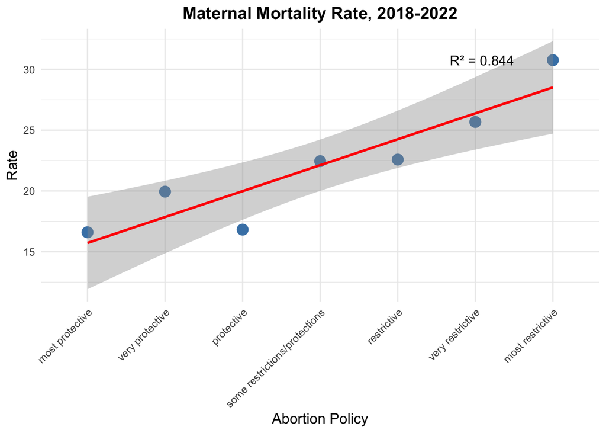

```r
print(maternal_mortality)
```

### Interpretation

R-squared is .844, very high correlation. Also way higher in most restrictive states.

### Ideas

1. Correlation plots with abortion policy, other columns I have not thought of yet.

```r
bachelors_or_higher <- create_policy_viz(df,
   "twenty_five_and_older_had_bachelors_by_higher_2021",
   "% 25 and older with a Bachelors or Higher, 2021",
   "Rate",
   "scatter")
```

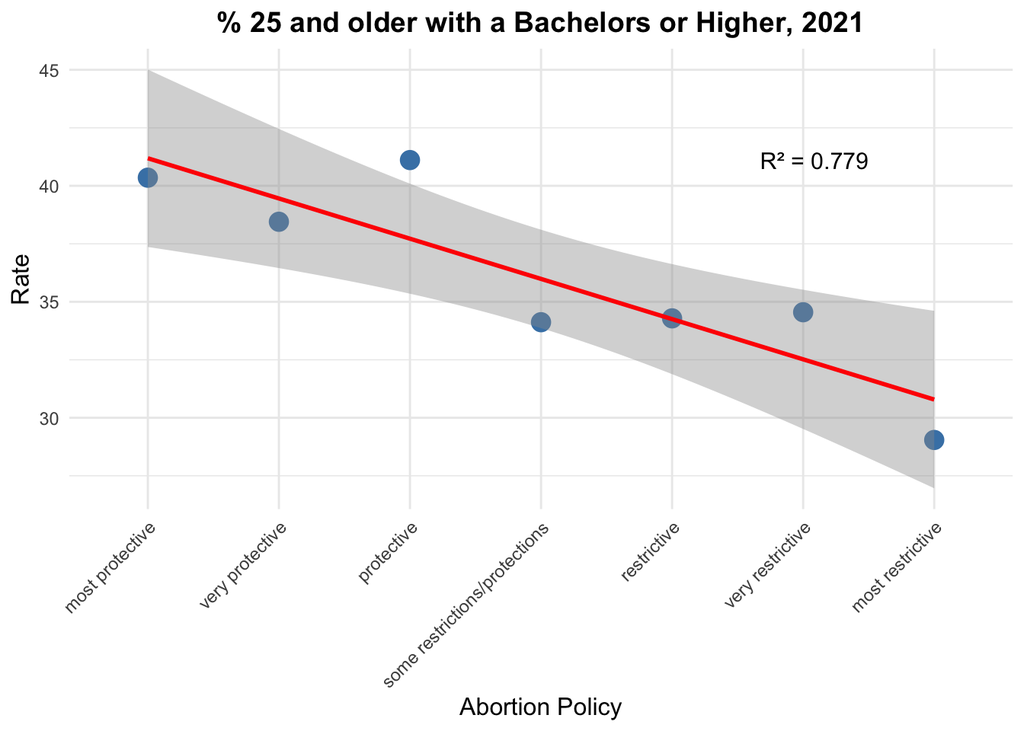

```r
print(bachelors_or_higher)
```

### Interpretation

R-squared is .779, strong negative correlation. Especially low for most restrictive states.

### Ideas

1. Correlation plots with teen birth, maternal workforce, healthcare, abortion policy, etc.

```r
concraception <- create_policy_viz(df,
   "state_requires_coverage_of_prescription_contraception",
   "State Requires Coverage of Prescription Coverage",
   "Rate",
   "scatter")
```

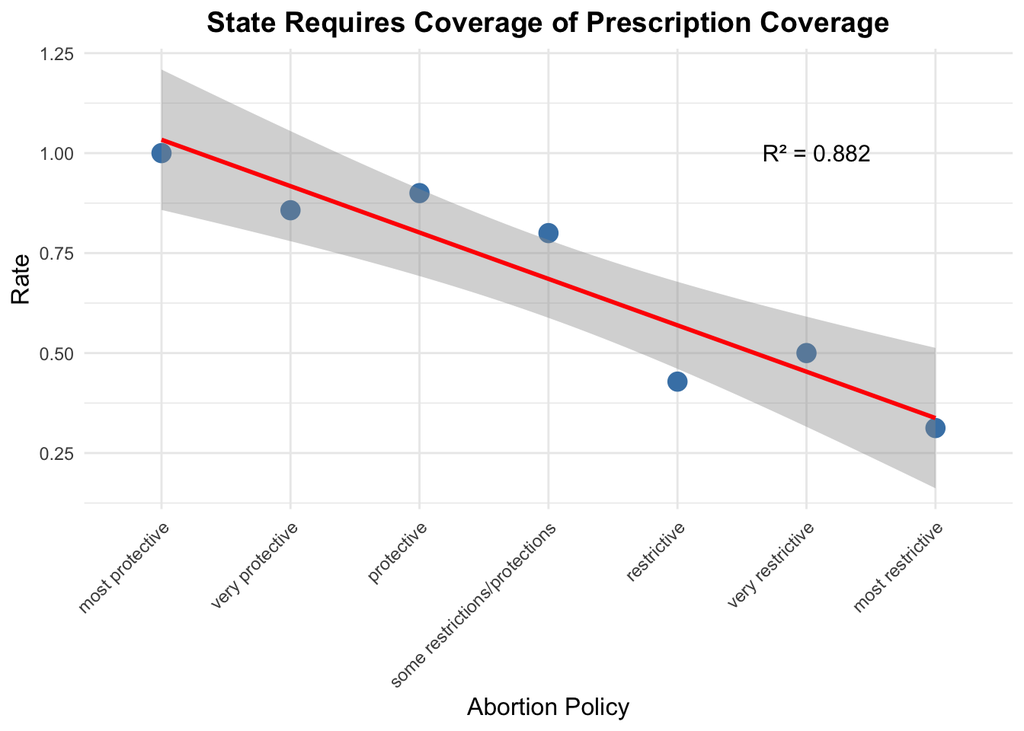

```r
print(concraception)
```

### Interpretation

R-squared is .882, very strong negative correlation

### Ideas

1. This is more of Courtney’s area, I think we should make an abortion map and put a star on the states that provide this.

## Proportion of OBGYN

```r
df$proportion_obgyns_to_women <- df$number_of_obstetricians_and_gynecologists_employed_2023 /
                                   df$total_sumber_of_women_aged_15_44_2017
```

```r
obgyn <- create_policy_viz(df,
   "proportion_obgyns_to_women",
   "State Requires Coverage of Prescription Coverage",
   "Rate",
   "scatter")
```

[figure not shown]

```r
print(obgyn)
```

### Interpretation

R-squared is .531, which is weak correlation. While this is not a great correlation, we can see from the chartt that the difference between having protections vs. restrictions is very big. What plot would be better for this?

### Ideas

1. Heatmap
2. Aggregate restrictive policies into one group and protective policies into another to focus on high-level differences.